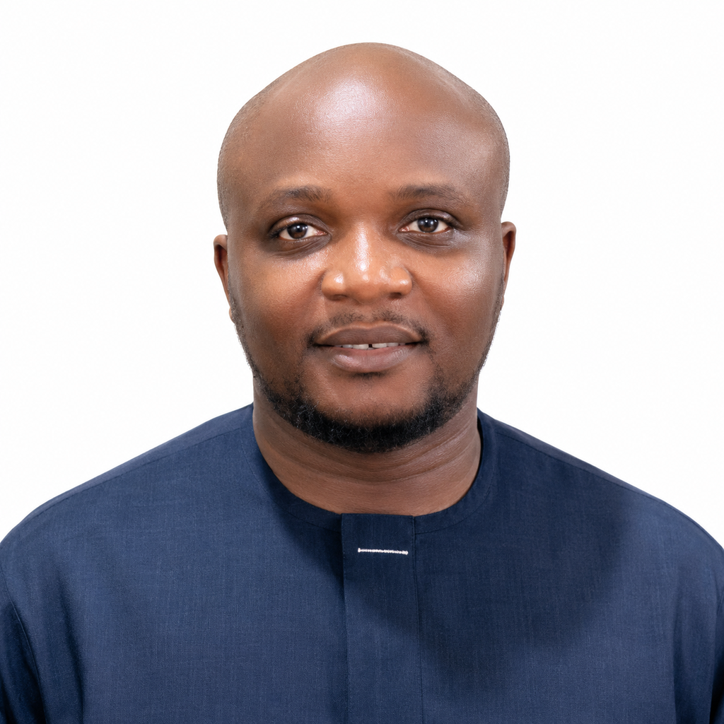

# Martin Okwumuo I.

## Data Scientist | Data Analyst | Business Intelligence | Operations Analytics

I analyze operational and business data to understand performance, identify inefficiencies and transform them into actionable insights through analytics, visualization to make better data-driven decisions. I equally build models using data and machine learning techniques to improve performance and efficiency.

📄 Resume

📊 Projects

[💻 GitHub](https://github.com/okwumuo-martin)

[💼 LinkedIn](https://www.linkedin.com/in/martin-okwumuo-137a3716a)

# Target Roles

**Data Analyst** | **Business Intelligence Analyst** | **Operations Data Analyst** | **Business Analyst** | **Supply Chain** | **Logistics Analyst** | **Junior Data Scientist**

## 3+

Portfolio Projects

## 2

Professional Certifications

## 5+

Years Business Experience

## 8+

Technical Tools

## Core Technologies

Python

R

SQL

Excel

Tableau

Git

Machine Learning

Power BI

# About Me

I am a Computer Science graduate with professional experience in logistics, operations, and business administration. My background has given me first-hand experience solving operational challenges, improving customer service, managing teams, and using data to support better business decisions.

After discovering the power of data analytics, I completed the Google Data Analytics Professional Certificate and the Johns Hopkins Data Science Specialization to strengthen my analytical and technical skills.

Today, I combine operational experience with analytics, SQL, R, Python, Excel, Tableau, and machine learning to transform raw business data into actionable insights that improve efficiency, reduce costs, and support smarter decision-making.

My projects demonstrate practical experience in exploratory data analysis, business intelligence dashboards, predictive analytics, machine learning, and operational analytics.

## 📊 Data Analytics

Transforming raw data into business insights using SQL, R, Python, Excel and Tableau.

## 🚚 Operations Analytics

Applying operational and logistics experience to identify inefficiencies, analyze performance and support better decisions.

## 🤖 Machine Learning

Building predictive models and data-driven solutions using statistical and machine learning techniques.

# Technical Skills

### 📊 R Programming

Data analysis, visualization, statistical modeling and reporting.

### 🗄 SQL

Data extraction, joins, aggregation and business reporting.

### 🐍 Python

Data analysis, automation and machine learning.

### 📈 Tableau

Interactive dashboards and business intelligence.

### 📑 Microsoft Excel

Advanced Excel, PivotTables, Power Query, dashboards, and business reporting.

### 🤖 Machine Learning

Regression, classification, predictive modeling, and model evaluation using R and Python.

### 📦 Git & GitHub

Version control and portfolio management.

### 📉 Data Visualization

Creating compelling charts and executive dashboards.

# Featured Projects

## U.S. Freight Transportation Analytics

Analyzed 599,529 freight-flow records across the United States using the Bureau of Transportation Statistics’ Freight Analysis Framework Version 6.0 (FAF6.0) 2022.

**Tools**

R | Git | GitHub | Tableau

**Data Source** U.S Bureau of Transportation Statistics [View Data Source](https://www.bts.gov/faf)

View Case Study

View EDA Report

[View Dashboard](https://public.tableau.com/views/U_S_FreightTransportAnalytics/U_SFreightTransportationAnalyticsDashboard?:showVizHome=no)

[View GitHub Repository](https://github.com/okwumuo-martin/U.S_Freight_Transportation_Analytics)

This project demonstrates an end-to-end analytics workflow, from data cleaning and transformation in R to interactive business intelligence in Tableau.

## Natural Language Next-word Prediction Model

A natural language next-word prediction model accompanied by an app which predicts the most likely next word when a user enters a word or a sentence; the same category of “invisible AI” behind phone keyboards, search auto-complete, and drafting assistants entirely from raw text, with no external APIs or pre-trained language models.

**Tools**

R | Git | GitHub | Shiny

**Data Source** Swiftkey/Coursera [Get Data](https://d396qusza40orc.cloudfront.net/dsscapstone/dataset/Coursera-SwiftKey.zip)

[View App](https://snndvl-martin-okwumuo.shinyapps.io/Text-Prediction-Model)

[View Slide](https://snndvl-martin-okwumuo.shinyapps.io/slide_deck)

View Case Study

View EDA Report

[View GitHub Repository](https://github.com/okwumuo-martin/Text-Prediction-Model)

This project covers the full life-cycle of a real data science project from exploratory analysis to a statistically grounded model architecture, performance debugging, held-out evaluation and a shipped, non-technical user friendly Shiny application.

## German Credit Risk Prediction

Predicting loan approval risk using machine learning and an interactive Shiny application. This project demonstrates how machine learning can be used to support the assessment of loan applicants. A Logistic Regression model is developed using the German Credit dataset and incorporated into an interactive Shiny application

**Tools**

R • Shiny • Machine Learning • ggplot2

**Data Source** GermanCredit Dataset in R

[View App](https://snndvl-martin-okwumuo.shinyapps.io/Loan_eligibility_predictor)

[View Slide](https://snndvl-martin-okwumuo.shinyapps.io/Loan_predictor_presentation)

View Case Study

View EDA Report

[View GitHub Repository](https://github.com/okwumuo-martin/German-Credit-Predictor)

A simple and interactive prediction system that demonstrates how statistical modelling can assist in credit assessment. From Raw data to data product.